# Meta-Analysis: When and How

From a pile of studies to one honest answer

Department of Community Medicine, AFMC Pune

18 November 2026

## Today’s plan

1. Why pool at all?
2. When **not** to do a meta-analysis
3. The workflow: question to extraction
4. Effect measures
5. Fixed vs random effects
6. Heterogeneity
7. Reading a forest plot
8. Subgroups and meta-regression
9. Small-study effects and funnel plots
10. Certainty of evidence (GRADE)
11. Doing it in R

One running example throughout: **13 trials of BCG vaccine for preventing tuberculosis.**

# Why meta-analysis?

## What is a meta-analysis?

- A **reproducible** method to answer a research question by collecting **all** available studies on it
- Uses **statistical techniques** to combine the results of individual studies
- Draws **new conclusions** from the pooled data

**Systematic review** = the whole process (question, search, appraisal, synthesis).  
**Meta-analysis** = the optional *statistical* step inside it.

Every meta-analysis should sit inside a systematic review. Not every systematic review needs a meta-analysis.

## Why combine studies?

- **Precision:** many small trials, each underpowered, together give a narrow CI
- **Consistency:** does the effect hold across settings, populations, doses?
- **Conflict resolution:** “positive” and “negative” trials can agree once pooled
- **New questions:** explore *why* results differ (subgroups, meta-regression)

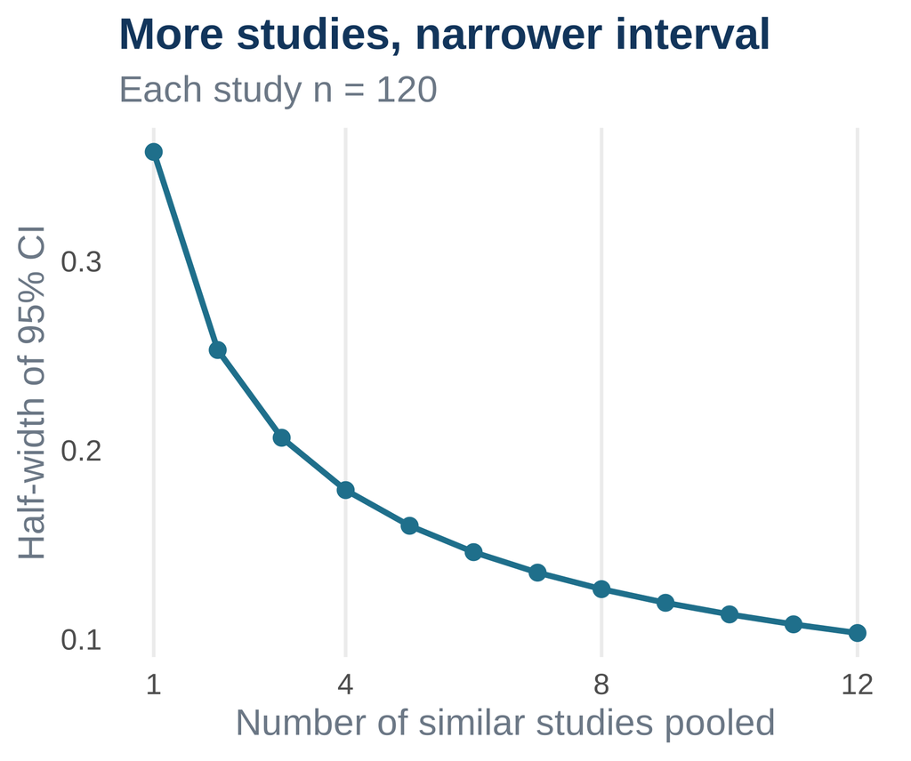

## When **not** to meta-analyse

- Studies answer **different questions** (apples and oranges)
- Outcomes are measured in ways that **can’t be put on one scale**
- Studies are at **high risk of bias** (garbage in, garbage out)
- **Very large, unexplained heterogeneity**: a single number would mislead
- **Selective reporting** has removed much of the evidence

A precise pooled estimate of **biased** studies is a precisely wrong answer. Narrative or structured synthesis (e.g. SWiM) is a legitimate alternative.

# The workflow

## From question to pooled estimate

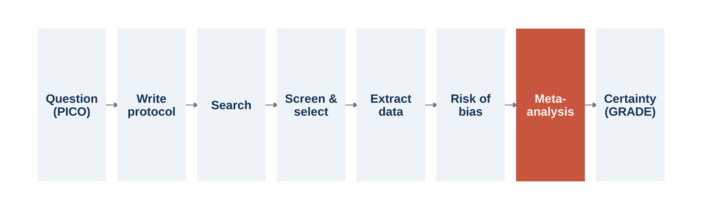

- Register the protocol (PROSPERO) **before** you see the results
- Report with **PRISMA 2020**: flow diagram, checklist, and the full search strategy

## Collecting data: what to abstract

| Category | Columns |
| --- | --- |
| Study info | Study ID, author, year, country, design |
| Population | Description, age (mean/range), sex (%) |
| Sample size | n intervention, n control |
| Intervention | Name & dose, comparator, follow-up |
| Outcome data | Events/totals, or mean & SD per arm |
| Effect estimates | Effect size, 95% CI, p-value |
| Quality | Risk of bias, conflicts of interest, funding |

Pilot the form on 2–3 studies, extract in **duplicate**, and write to investigators for missing data.

## Keep the data tidy

One row per study, one column per variable. This is what our BCG data look like:

| Study | TB (vacc.) | No TB (vacc.) | TB (ctrl) | No TB (ctrl) | Latitude | Allocation |
| --- | --- | --- | --- | --- | --- | --- |
| Aronson (1948) | 4 | 119 | 11 | 128 | 44 | random |
| Ferguson & Simes (1949) | 6 | 300 | 29 | 274 | 55 | random |
| Rosenthal et al (1960) | 3 | 228 | 11 | 209 | 42 | random |
| Hart & Sutherland (1977) | 62 | 13536 | 248 | 12619 | 52 | random |
| Frimodt-Moller et al (1973) | 33 | 5036 | 47 | 5761 | 13 | alternate |
| Stein & Aronson (1953) | 180 | 1361 | 372 | 1079 | 44 | alternate |
| Vandiviere et al (1973) | 8 | 2537 | 10 | 619 | 19 | random |

… 13 trials in all. `dat.bcg` ships with the **metafor** package (Colditz et al., *JAMA* 1994).

## Risk of bias comes before pooling

**Within studies (RoB 2 / ROBINS-I)**

- Randomisation & allocation concealment
- Deviations from intended intervention
- Missing outcome data
- Measurement of the outcome
- Selective reporting

**Across studies (reporting biases)**

- Publication bias
- Time-lag bias
- Language bias
- Citation bias
- Duplicate publication
- Location bias

Use RoB judgements in the analysis: sensitivity analysis excluding high-risk studies, or subgroup by RoB.

# Effect measures

## Choosing an effect measure

| Outcome type | Common measures | Example |
| --- | --- | --- |
| Dichotomous | **Risk ratio**, odds ratio, risk difference | TB yes/no |
| Continuous, same scale | **Mean difference (MD)** | SBP in mmHg |
| Continuous, different scales | **Standardised MD** (Hedges’ *g*) | Depression scores |
| Time to event | **Hazard ratio** | Survival |
| Counts & rates | Rate ratio | Falls per person-year |

Ratio measures are pooled on the **log scale** and back-transformed for presentation.

## Computing a study’s effect: the 2 × 2 table

|  | Event | No event |
| --- | --- | --- |
| **Vaccine** | *a* | *b* |
| **Control** | *c* | *d* |

$$\text{RR} = \frac{a/(a+b)}{c/(c+d)}$$

$$\operatorname{Var}(\ln \text{RR}) = \tfrac{1}{a} - \tfrac{1}{a+b} + \tfrac{1}{c} - \tfrac{1}{c+d}$$

```r
bcg_es <- bcg |>
  mutate(
    yi  = log((tpos / (tpos + tneg)) /
              (cpos / (cpos + cneg))),
    vi  = 1/tpos - 1/(tpos + tneg) +
          1/cpos - 1/(cpos + cneg),
    sei = sqrt(vi)
  )

# or let metafor do it:
escalc(measure = "RR",
       ai = tpos, bi = tneg,
       ci = cpos, di = cneg,
       data = bcg)
```

# Pooling: fixed vs random effects

## Meta-analysis is a two-stage process

1. **Stage 1:** compute an effect estimate $y_i$ and its variance $v_i$ for **each study**
2. **Stage 2:** combine them as a **weighted average**

$$\hat\theta = \frac{\sum_i w_i \, y_i}{\sum_i w_i}, \qquad w_i = \frac{1}{v_i}
\qquad \text{SE}(\hat\theta) = \frac{1}{\sqrt{\sum_i w_i}}$$

**Inverse-variance weighting:** precise (usually larger) studies count for more. It is *not* a simple average and *not* pooling of raw patients.

## Inverse-variance pooling by hand, the tidy way

```r
pooled_fe <- bcg_es |>
  mutate(wi = 1 / vi) |>
  summarise(
    theta = sum(wi * yi) / sum(wi),
    se    = sqrt(1 / sum(wi))
  ) |>
  mutate(
    RR    = exp(theta),
    lower = exp(theta - 1.96 * se),
    upper = exp(theta + 1.96 * se)
  )
pooled_fe
```

```
# A tibble: 1 × 5
   theta     se    RR lower upper
   <dbl>  <dbl> <dbl> <dbl> <dbl>
1 -0.430 0.0405 0.650 0.601 0.704
```

Identical to `rma(yi, vi, data = bcg_es, method = "FE")`: pooled RR = 0.65 (95% CI 0.60 to 0.70).

## Two models, two different questions

**Fixed (common) effect**

- One true effect $\theta$ shared by all studies
- Differences between studies = **sampling error only**
- Answers: *“What is the best estimate of this common effect?”*
- Methods: inverse variance, Mantel–Haenszel, Peto

**Random effects**

- True effects **vary** across studies: $\theta_i \sim N(\mu, \tau^2)$
- Two sources of variation: within ($v_i$) + between ($\tau^2$)
- Answers: *“What is the **average** effect, and how much does it vary?”*
- Weights: $w_i^* = 1 / (v_i + \tau^2)$

Choose the model on **conceptual** grounds in your protocol, not after peeking at *I*².

## Random effects spreads the weight

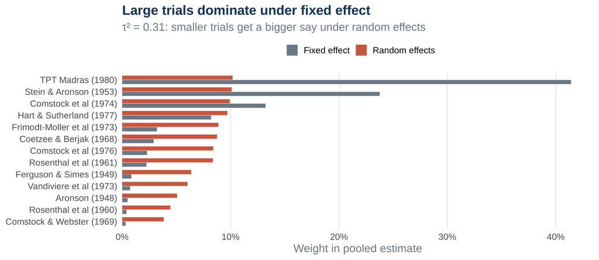

## Estimating the between-study variance τ²

| Estimator | Notes |
| --- | --- |
| DerSimonian–Laird (DL) | Classic, simple; underestimates τ² when *k* is small |
| **REML** | Recommended default in most software today |
| Paule–Mandel | Good alternative, also recommended |

**Hartung–Knapp (HKSJ) adjustment** widens the CI to reflect uncertainty in τ², especially with few studies.

| Method | Pooled RR | 95% CI | τ² |
| --- | --- | --- | --- |
| DL | 0.49 | 0.34 to 0.70 | 0.309 |
| REML | 0.49 | 0.34 to 0.70 | 0.313 |
| REML + HKSJ | 0.49 | 0.33 to 0.73 | 0.313 |

# Heterogeneity

## Is the variation more than chance?

- **Visual:** do the CIs overlap?
- **Cochran’s Q:** $Q = \sum w_i (y_i - \hat\theta)^2$, tests $H_0$: all studies share one effect. Low power with few studies.
- *I*² $= \frac{Q - df}{Q}$: % of variability due to real differences, not chance
- **τ²:** the *size* of the between-study variance, on the effect scale

| *I*² | Rough guide (Cochrane) |
| --- | --- |
| 0–40% | might not be important |
| 30–60% | moderate |
| 50–90% | substantial |
| 75–100% | considerable |

BCG: Q = 152.2 (df = 12), *I*² = 92%, τ² = 0.31

## Same pooled effect, very different stories

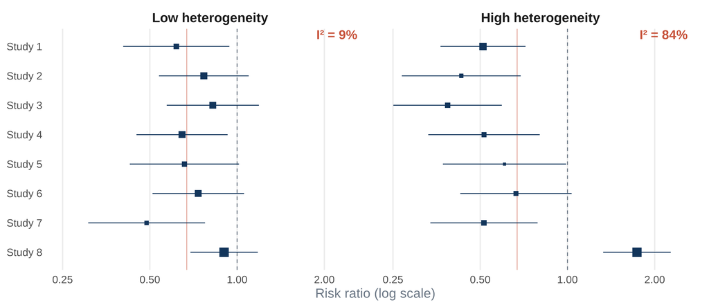

## Prediction interval: where the *next* study may land

- The CI tells us about the **average** effect
- The **95% prediction interval** tells us the range of true effects in a **new setting**

BCG pooled RR = **0.49** (95% CI 0.34 to 0.70)  
95% prediction interval: **0.15 to 1.55**

On average BCG protects, but in some settings it may do little or nothing. Report the prediction interval whenever you fit a random-effects model.

# Reading a forest plot

## The BCG forest plot

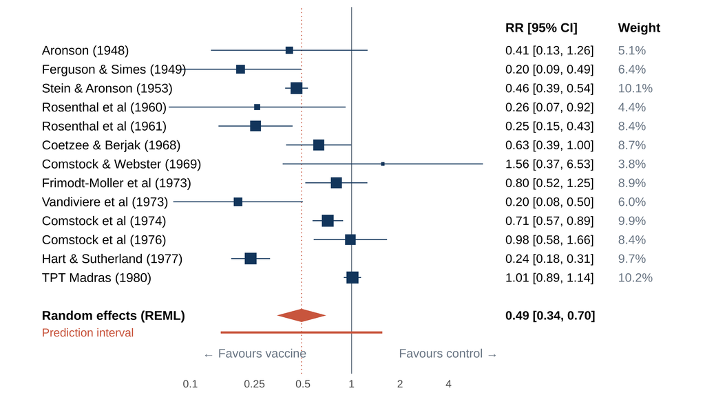

## Anatomy of a forest plot

- **Square** = point estimate of each study; **size** ∝ weight
- **Horizontal line** = 95% CI of that study
- **Vertical line at 1** (ratio) or 0 (difference) = line of no effect
- **Diamond** = pooled estimate; **width** = its 95% CI
- **Prediction interval** = expected range of true effects in a new setting
- Look for: direction, overlap of CIs, outliers, and the heterogeneity statistics

Ask: *Do most studies point the same way? Is the diamond clear of the null? How wide is the spread?*

# Explaining heterogeneity

## Subgroup analysis

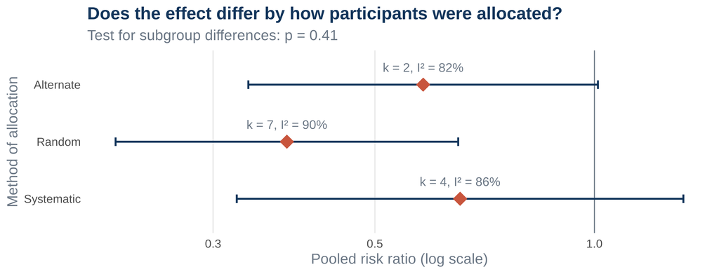

Pre-specify subgroups, keep them few, and compare them with a **formal interaction test**, not by eyeballing p-values.

## Meta-regression: effect vs latitude

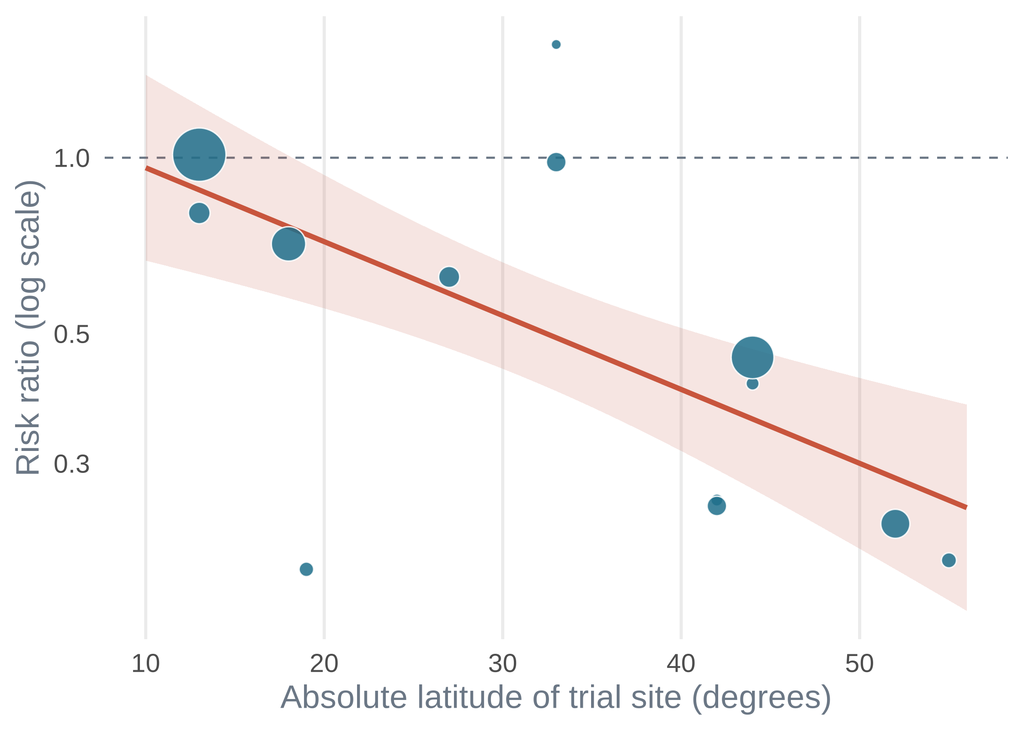

- Bubble size = study precision
- Further from the equator, **more** protection
- Latitude explains **76%** of the between-study variance (*R*²)
- Needs ~10 studies per covariate
- Observational: **study-level** associations can mislead (ecological bias)

## Sensitivity analysis: leave one out

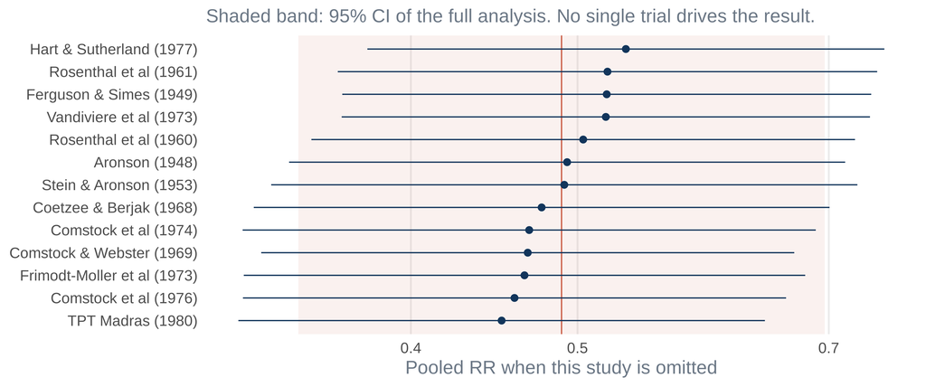

Also re-run excluding high risk-of-bias studies, using a different model, or a different effect measure.

# Small-study effects

## The funnel plot

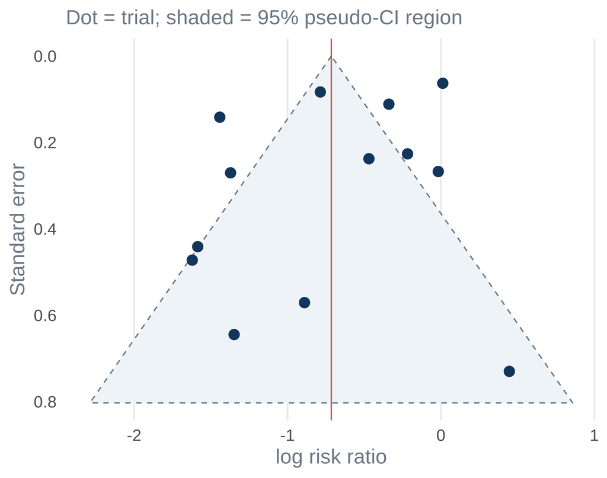

- Large studies sit at the **top**, near the pooled effect
- Small studies scatter more widely at the **bottom**
- **Asymmetry** (a missing corner) suggests small-study effects, e.g. publication bias
- But asymmetry also arises from heterogeneity, chance or poor quality
- Need **≥ 10 studies** to interpret

## Testing and adjusting for asymmetry

| Method | What it does | BCG result |
| --- | --- | --- |
| **Egger’s test** | Regresses effect on its SE; slope ≠ 0 signals asymmetry | p = 0.42 |
| Begg’s test | Rank correlation version | Lower power |
| **Trim-and-fill** | Imputes “missing” studies to make the funnel symmetric | 1 study added; RR 0.49 → 0.52 |

These are **sensitivity analyses**, not corrections. Searching trial registries and grey literature does more to prevent publication bias than any test.

# Certainty of evidence: GRADE

## From pooled estimate to recommendation

RCTs start at **High**, observational studies at **Low**; final rating: **High · Moderate · Low · Very low**.

**Rate down** for

1. **Risk of bias**
2. **Inconsistency** (heterogeneity, *I*²)
3. **Indirectness** (PICO mismatch)
4. **Imprecision** (wide CI, few events)
5. **Publication bias**

**Rate up** (mainly observational) for

1. **Large magnitude** of effect
2. **Dose–response** gradient
3. **Plausible confounding** would reduce the effect

Present the ratings, outcome by outcome, in a *Summary of Findings* table (GRADEpro).

## Where meta-analysis meets GRADE

| Domain | What the meta-analysis shows you | BCG |
| --- | --- | --- |
| Risk of bias | RoB judgements; sensitivity analysis by RoB | Some trials used alternation |
| Inconsistency | Forest plot overlap, I², τ², prediction interval | I² = 92%: partly explained by latitude |
| Indirectness | Do the studies match your PICO? | Mixed populations and decades |
| Imprecision | Width of the pooled CI vs decision thresholds | CI 0.34 to 0.70 |
| Publication bias | Funnel plot, Egger, trim-and-fill | No strong signal |

Illustrative only. A real GRADE assessment is done per outcome by the review team.

# Doing it in R

## A complete meta-analysis in a few lines

```r
library(tidyverse)
library(metafor)

res <- dat.bcg |>
  escalc(measure = "RR", ai = tpos, bi = tneg, ci = cpos, di = cneg,
         data = _, slab = paste0(author, " (", year, ")")) |>
  rma(yi, vi, data = _, method = "REML", test = "knha")   # random effects + HKSJ

res                                 # pooled estimate, tau^2, I^2, Q
predict(res, transf = exp)          # RR with CI and prediction interval
forest(res, atransf = exp)          # forest plot
funnel(res); regtest(res)           # funnel plot and Egger's test
rma(yi, vi, mods = ~ ablat, data = res$data)   # meta-regression
leave1out(res, transf = exp)        # sensitivity analysis
```

The **meta** package (`metabin()`, `metacont()`, `metagen()`) gives Cochrane-style output with the same ideas. See Schwarzer, Carpenter & Rücker, *Meta-Analysis with R* (Springer, 2015).

## Software options

| Tool | Strengths |
| --- | --- |
| **R: metafor, meta** | Free, reproducible, every method in this talk and more |
| RevMan (Cochrane) | Standard for Cochrane reviews; GRADEpro integration |
| Stata (`meta`) | Good built-in suite |
| JASP / jamovi | Point-and-click front ends to metafor |
| GRADEpro GDT | Summary of Findings tables and evidence profiles |

## Common pitfalls

- Pooling studies that answer **different questions**
- Choosing fixed vs random **after** seeing *I*²
- Treating *I*² as an absolute measure of heterogeneity (it depends on study precision)
- Double-counting arms of multi-arm trials
- Mixing change scores and final values with the SMD
- Data-dredging through many unplanned subgroups
- Ignoring risk of bias in the synthesis
- Reporting a pooled estimate without a **prediction interval**

## Take-home messages

A meta-analysis is only as good as the systematic review behind it.

1. Ask whether pooling makes sense **before** you pool
2. Inverse-variance weighting: precise studies count for more
3. Random effects estimates an **average**; report τ² and the prediction interval
4. Heterogeneity is information: try to **explain** it
5. Funnel plots and Egger’s test are sensitivity checks, not proof
6. Finish with **GRADE**: how sure are we?

## Resources

- *Cochrane Handbook for Systematic Reviews of Interventions*, v6.5: training.cochrane.org/handbook
- Schwarzer G, Carpenter JR, Rücker G. *Meta-Analysis with R*. Springer, 2015
- Harrer M et al. *Doing Meta-Analysis with R: A Hands-On Guide*: [bookdown.org/MathiasHarrer/Doing_Meta_Analysis_in_R](https://bookdown.org/MathiasHarrer/Doing_Meta_Analysis_in_R/)
- Viechtbauer W. metafor package: metafor-project.org
- PRISMA 2020 statement: prisma-statement.org
- GRADE Learning Hub: [macgrade.mcmaster.ca](https://macgrade.mcmaster.ca/grade-learning-hub/grade-for-systematic-reviews/)
- GRADEpro: gradepro.org
- Colditz GA et al. Efficacy of BCG vaccine in the prevention of tuberculosis. *JAMA* 1994;271:698–702

# Thank you

Questions?